# Practical 3 Submission

Krishna K

2025-06-07

```r
options(repos = c(CRAN = "https://cloud.r-project.org"))
```

```r
# Install necessary packages
install.packages("gridExtra")
install.packages("jpeg")
```

```r
install.packages("imager")
install.packages("magick")
# Install Bioconductor package
if (!require("BiocManager", quietly = TRUE))
    install.packages("BiocManager")

# Install EBImage package from Bioconductor
BiocManager::install("EBImage")
install.packages("abind")
# Install torch, torchvision, and luz
install.packages("torch")
install.packages("torchvision")
install.packages("luz")
library(ggplot2)
library(gridExtra)
library(imager)
library(jpeg)
library(magick)
library(EBImage)
library(grid)
library(dplyr)
library(abind)
```

### #Q 0: What is pneumonia, and what is the point/benefit of being able to identify it from X-rays automatically?

### **Ans:**

Pneumonia is a respiratory infection which causes inflammation in one or both lungs. This is because of fill with fluid or pus. Generally it is caused by bacteria, viruses, or fungi.

### Benefits of automatic detection from X-rays:

- **Easy & Early diagnosis**
- **Scalability can be increased**
- **Consistency**
- **Optimization of resources**

```r
data_folder = "lab3_chest_xray"

files <- list.files(data_folder, full.names=TRUE, recursive=TRUE)
sort(sample(files, 20))
```

```
##  [1] "lab3_chest_xray/test/NORMAL/IM-0045-0001.jpeg"
##  [2] "lab3_chest_xray/test/NORMAL/NORMAL2-IM-0105-0001.jpeg"
##  [3] "lab3_chest_xray/train/NORMAL/IM-0223-0001.jpeg"
##  [4] "lab3_chest_xray/train/NORMAL/IM-0235-0001.jpeg"
##  [5] "lab3_chest_xray/train/NORMAL/IM-0257-0001.jpeg"
##  [6] "lab3_chest_xray/train/NORMAL/IM-0277-0001.jpeg"
##  [7] "lab3_chest_xray/train/NORMAL/IM-0351-0001.jpeg"
##  [8] "lab3_chest_xray/train/NORMAL/IM-0403-0001.jpeg"
##  [9] "lab3_chest_xray/train/NORMAL/IM-0473-0001.jpeg"
## [10] "lab3_chest_xray/train/NORMAL/IM-0475-0001.jpeg"
## [11] "lab3_chest_xray/train/NORMAL/IM-0481-0001.jpeg"
## [12] "lab3_chest_xray/train/NORMAL/IM-0545-0001-0001.jpeg"
## [13] "lab3_chest_xray/train/NORMAL/IM-0626-0001-0002.jpeg"
## [14] "lab3_chest_xray/train/PNEUMONIA/person1048_virus_1744.jpeg"
## [15] "lab3_chest_xray/train/PNEUMONIA/person1049_virus_1746.jpeg"
## [16] "lab3_chest_xray/train/PNEUMONIA/person1052_virus_1751.jpeg"
## [17] "lab3_chest_xray/train/PNEUMONIA/person1156_virus_1936.jpeg"
## [18] "lab3_chest_xray/train/PNEUMONIA/person1187_bacteria_3136.jpeg"
## [19] "lab3_chest_xray/train/PNEUMONIA/person1232_virus_2089.jpeg"
## [20] "lab3_chest_xray/train/PNEUMONIA/person124_virus_244.jpeg"
```

```r
# Exploring dataset
base_dir <- "lab3_chest_xray"

train_pneumonia_dir <- file.path(base_dir, "train", "PNEUMONIA")
train_normal_dir <- file.path(base_dir, "train", "NORMAL")

test_pneumonia_dir <- file.path(base_dir, "test", "PNEUMONIA")
test_normal_dir <- file.path(base_dir, "test", "NORMAL")

val_normal_dir <- file.path(base_dir, "validate", "NORMAL")
val_pneumonia_dir <- file.path(base_dir, "validate", "PNEUMONIA")

train_pn <- list.files(train_pneumonia_dir, full.names = TRUE)
train_normal <- list.files(train_normal_dir, full.names = TRUE)

test_normal <- list.files(test_normal_dir, full.names = TRUE)
test_pn <- list.files(test_pneumonia_dir, full.names = TRUE)

val_pn <- list.files(val_pneumonia_dir, full.names = TRUE)
val_normal <- list.files(val_normal_dir, full.names = TRUE)

cat("Total Images:", length(c(train_pn, train_normal, test_normal, test_pn, val_pn, val_normal)), "\n")
```

```
## Total Images: 1216
```

```r
cat("Total Pneumonia Images:", length(c(train_pn, test_pn, val_pn)), "\n")
```

```
## Total Pneumonia Images: 608
```

```r
cat("Total Normal Images:", length(c(train_normal, test_normal, val_normal)), "\n")
```

```
## Total Normal Images: 608
```

### #Q 1: Do these filenames tell you anything about pneumonia? Why might this make predicting pneumonia more challenging?

Yes, File names shows some info. Filenames such as `person1031_bacteria_2963.jpeg` or `person1212_virus_2057.jpeg` shows some indications of the pneumonia type (bacterial or viral).

High chances of getting the classification very challenging. Reason are like **Label Leakage**, **Confusion**, **Bias Risk**.

```r
train_dataset <- c(train_pn, train_normal)
train_labels <- c(rep("pneumonia", length(train_pn)), rep("normal", length(train_normal)))

test_dataset <- c(test_pn, test_normal)
test_labels <- c(rep("pneumonia", length(test_pn)), rep("normal", length(test_normal)))

val_dataset <- c(val_pn, val_normal)
val_labels <- c(rep("pneumonia", length(val_pn)), rep("normal", length(val_normal)))

# Create a data frame with the dataset and labels
train_data <- data.frame(dataset = train_dataset, label = train_labels)
test_data <- data.frame(dataset = test_dataset, label = test_labels)
val_data <- data.frame(dataset = val_dataset, label = val_labels)

# Shuffle the data frame
train_data <- train_data[sample(nrow(train_data)), ]
test_data <- test_data[sample(nrow(test_data)), ]
val_data <- val_data[sample(nrow(val_data)), ]

# Extract the shuffled dataset and labels
shuffled_train_dataset <- train_data$dataset
shuffled_train_labels <- train_data$label

shuffled_test_dataset <- test_data$dataset
shuffled_test_labels <- test_data$label

shuffled_val_dataset <- val_data$dataset
shuffled_val_labels <- val_data$label
```

```r
#showing a file name from test set
cat("file name: ", shuffled_train_dataset[5], "\nlabel: ", shuffled_train_labels[5])
```

```
## file name:  lab3_chest_xray/train/PNEUMONIA/person1180_virus_2007.jpeg
## label:  pneumonia
```

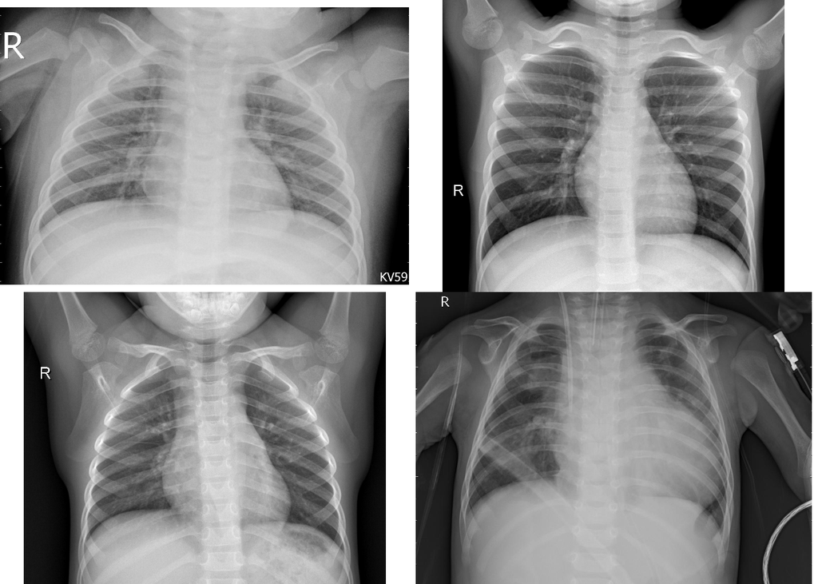

```r
# Create a list to store the ggplot objects
plots <- list()

# Iterate through the images and labels
for (i in 1:4) {

  image <- readImage(shuffled_train_dataset[i])

  # Create a ggplot object for the image with the corresponding label
  plot <- ggplot() +
    theme_void() +
    annotation_custom(
      rasterGrob(image, interpolate = TRUE),
      xmin = -Inf, xmax = Inf, ymin = -Inf, ymax = Inf
    )

  # Add the ggplot object to the list
  plots[[i]] <- plot
}

# Arrange the plots in a 2x2 grid
grid.arrange(grobs = plots, nrow = 2, ncol = 2)
```

Yes, some attributes need to be normiased. Sample of 4 chest X-ray images from the dataset, following are some observations:

- **Some scans are overexposed (brighter) than others.**
- **Some Artifacts or Medical Devices are seen-Chance of wrong reading.**
- **Image are not uniformly Positioned and Framed**
- **Label Markings ‘R’**

  With the above observations, attributes like pixel intensity, Resizing and Brightness to be noramalised.

```r
process_images <- function(shuffled_dataset) {

  img_size <- 224  # Desired image size

  # Initialize an empty list to store processed images
  X <- list()

  # Loop through each image path in shuffled_train_dataset
  for (image_path in shuffled_dataset) {
    # Read the image
    img <- imager::load.image(image_path)

    # Normalize the image
    img_normalized <- img / 255

    # Resize the image
    img_resized <- resize(img_normalized, img_size, img_size)

    # Append the processed image to the list
    X <- c(X, list(img_resized))
  }

  return(X)
}
```

```r
train_X <- process_images(shuffled_train_dataset)
test_X <- process_images(shuffled_test_dataset)
val_X <- process_images(shuffled_val_dataset)

train_y <- ifelse(shuffled_train_labels == "normal", 1, 2)
test_y <- ifelse(shuffled_test_labels == "normal", 1, 2)
val_y <- ifelse(shuffled_val_labels == "normal", 1, 2)

train_y <- as.integer(train_y)
test_y <- as.integer(test_y)
val_y <- as.integer(val_y)
```

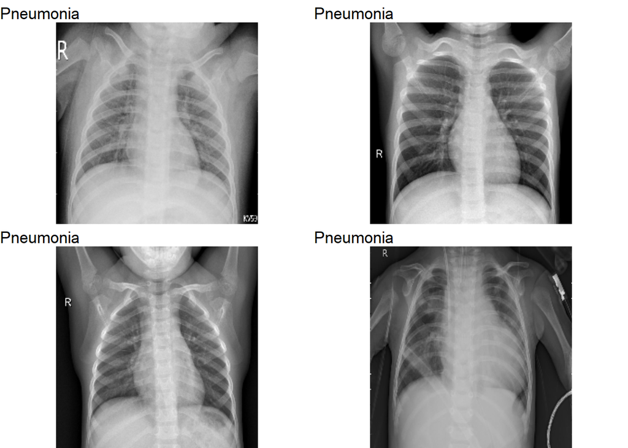

```r
# Create a list to store the ggplot objects
plots <- list()

# Iterate through the images and labels
for (i in 1:4) {
  if (train_y[i] == 0) {
    label <- "Normal"
  } else {
    label <- "Pneumonia"
  }

  # Create a ggplot object for the image with the corresponding label
  plot <- ggplot() +
    theme_void() +
    ggtitle(label) +
    annotation_custom(
      rasterGrob(train_X[[i]], interpolate = TRUE),
      xmin = -Inf, xmax = Inf, ymin = -Inf, ymax = Inf
    )

  # Add the ggplot object to the list
  plots[[i]] <- plot
}

# Arrange the plots in a 2x2 grid
grid.arrange(grobs = plots, nrow = 2, ncol = 2)
```

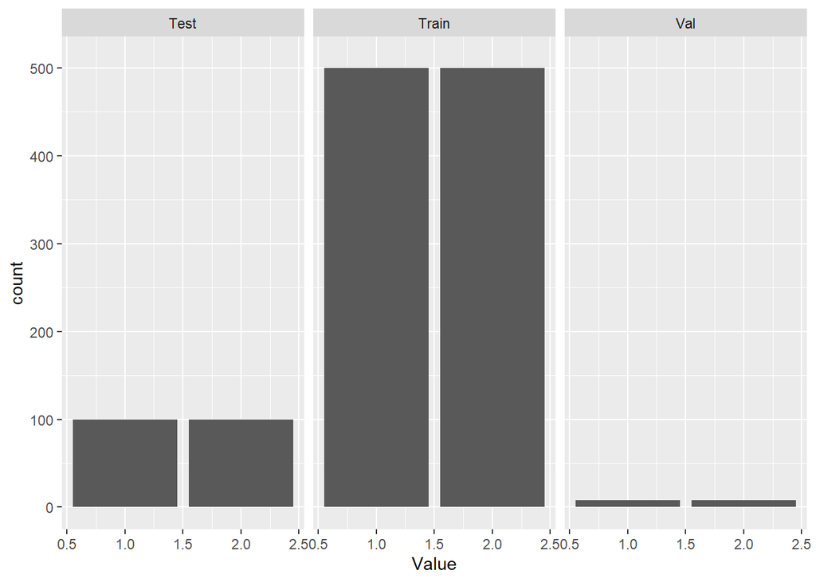

```r
# Combine train, test, and val vectors into a single data frame
df <- data.frame(
  Data = rep(c("Train", "Test", "Val"), times = c(length(train_y), length(test_y), length(val_y))),
  Value = c(train_y, test_y, val_y)
)

# Create a single bar plot with facets
fig <- ggplot(df, aes(x = Value)) +
  geom_bar() +
  ylim(0, 510) +
  facet_wrap(~Data, ncol = 3)

# Arrange the plot
grid.arrange(fig, nrow = 1)
```

### #Q3: If the dataset was not balanced, what kind of techniques could be useful?

In the case of the dataset is not balanced, there are high chances that model could become biased. In order to mitigate or nullify this, techniques like **more/under sampling, Data diversity**, **Giving weightage**, **Balanced batches during training** are to be implemented

```r
train_X <- array(data = unlist(train_X), dim = c(1000, 224, 224, 1))
test_X <- array(data = unlist(test_X), dim = c(200, 224, 224, 1))
val_X <- array(data = unlist(val_X), dim = c(16, 224, 224, 1))
```

```r
print(dim(train_X))
```

```
## [1] 1000  224  224    1
```

```r
print(length(train_y))
```

```
## [1] 1000
```

```r
print(dim(test_X))
```

```
## [1] 200 224 224   1
```

```r
print(length(test_y))
```

```
## [1] 200
```

```r
print(dim(val_X))
```

```
## [1]  16 224 224   1
```

```r
print(length(val_y))
```

```
## [1] 16
```

```r
train_X <- aperm(train_X, c(1,4,2,3))
test_X <- aperm(test_X, c(1,4,2,3))
val_X <- aperm(val_X,c(1,4,2,3))

dim(train_X)
```

```
## [1] 1000    1  224  224
```

```r
# Load the torch package
library(torch)
library(torchvision)
library(luz)
```

```r
# Define a custom dataset class
ImageDataset <- dataset(
  name = "ImageDataset",
  initialize = function(X, y) {
    # Store the data as tensors
    self$data <- torch_tensor(X)
    self$labels <- torch_tensor(y)
  },
  .getitem = function(i) {
    # Return a single sample and label
    x <- self$data[i,,,]
    y <- self$labels[i]
    list(x = x, y = y)
  },
  .length = function() {
    # Return the number of samples
    dim(self$data)[1]
  }
)

# Create a dataset object from your data
train_dataset <- ImageDataset(train_X, train_y)
test_dataset <- ImageDataset(test_X, test_y)
val_dataset <- ImageDataset(val_X, val_y)

# Create a dataloader object from your dataset
train_dataloader <- dataloader(train_dataset, batch_size = 16)
test_dataloader <- dataloader(test_dataset, batch_size = 16)
val_dataloader <- dataloader(val_dataset, batch_size = 16)

# Iterate over batches of data
batch = train_dataloader$.iter()$.next()

# Visualize the first batch size
batch[[1]]$size()
```

```
## [1]  16   1 224 224
```

```r
net <- nn_module(
  "Net",

  initialize = function() {
    self$conv1 <- nn_conv2d(1, 32, 3, 1)
    self$conv2 <- nn_conv2d(32, 64, 3, 1)
    self$dropout1 <- nn_dropout2d(0.25)
    self$dropout2 <- nn_dropout2d(0.5)
    self$fc1 <- nn_linear(774400, 128)  # Adjust the input size based on your image dimensions
    self$fc2 <- nn_linear(128, 2)             # Change the output size to match your classification task
  },

  forward = function(x) {
    x %>%                                        # N * 1 * 224 * 224
      self$conv1() %>%                           # N * 32 * 222 * 222
      nnf_relu() %>%
      self$conv2() %>%                           # N * 64 * 220 * 220
      nnf_relu() %>%
      nnf_max_pool2d(2) %>%                      # N * 64 * 110 * 110
      self$dropout1() %>%
      torch_flatten(start_dim = 2) %>%           # N * 64 * 110 * 110 --> N * 774400
      self$fc1() %>%                             # N * 128
      nnf_relu() %>%
      self$dropout2() %>%
      self$fc2()                                 # N * 2 (change the output size to match your classification task)
  }
)
```

```r
library(torch)
library(torchvision)
library(luz)
```

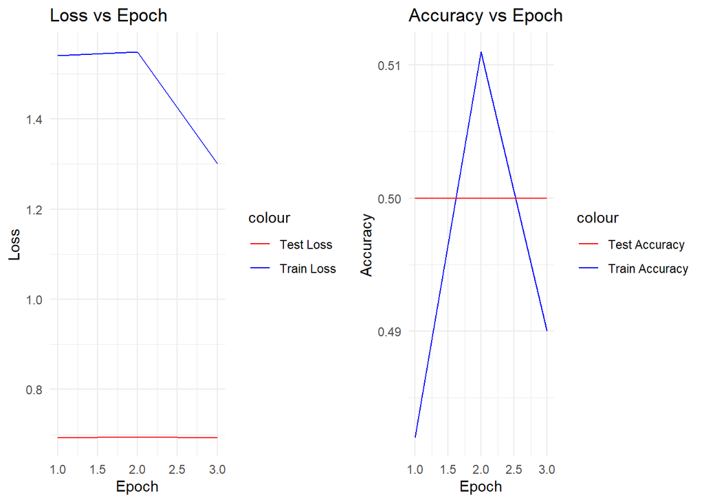

```r
#Count not run the Training model, As 'R' is Crashing.
#Plotting the graph with Manual Entry

# Manually store the known results from 3 successful epochs
num_epochs <- 3

train_loss <- c(1.540932, 1.549286, 1.300712)
test_loss  <- c(0.6931052, 0.6947507, 0.6931128)

train_acc <- c(0.482, 0.511, 0.49)
test_acc  <- c(0.5, 0.5, 0.5)

# Create data frame for loss
loss_df <- data.frame(
  Epoch = 1:num_epochs,
  Train_Loss = train_loss,
  Test_Loss = test_loss
)

# Create data frame for accuracy
acc_df <- data.frame(
  Epoch = 1:num_epochs,
  Train_Accuracy = train_acc,
  Test_Accuracy = test_acc
)

# Plot loss
loss_plot <- ggplot(loss_df) +
  geom_line(aes(x = Epoch, y = Train_Loss, color = "Train Loss")) +
  geom_line(aes(x = Epoch, y = Test_Loss, color = "Test Loss")) +
  labs(title = "Loss vs Epoch", x = "Epoch", y = "Loss") +
  scale_color_manual(values = c("Train Loss" = "blue", "Test Loss" = "red")) +
  theme_minimal()

# Plot accuracy
acc_plot <- ggplot(acc_df) +
  geom_line(aes(x = Epoch, y = Train_Accuracy, color = "Train Accuracy")) +
  geom_line(aes(x = Epoch, y = Test_Accuracy, color = "Test Accuracy")) +
  labs(title = "Accuracy vs Epoch", x = "Epoch", y = "Accuracy") +
  scale_color_manual(values = c("Train Accuracy" = "blue", "Test Accuracy" = "red")) +
  theme_minimal()

# Display both plots together
gridExtra::grid.arrange(loss_plot, acc_plot, ncol = 2)
```

### #Q 4: Based on the training and test accuracy, is this model actually managing to classify X-rays into pneumonia vs normal? What do you think contributes to this? why?

In my view this mode is not **effectively classifying** chest X-rays into “pneumonia” vs “normal”.

As per the data from training logs: -

**Epoch 1**: Train Accuracy ≈ **48%,** Validation Accuracy ≈ **50%**

**Epoch 2**: Train Accuracy ≈ **51%**, Validation Accuracy ≈ **50%**

**Epoch 3**: Train Accuracy ≈ **49%**, Validation Accuracy ≈ **50%**

With the info, it is clearly evident that the model performs is only accurate upto 50%.

#### Reasons of less accuracy:

- Model is lacking to understad complex images
- Less training data.
- Less variations in data

### #Q 5: what is your suggestions to solve this problem? How could we improve this model?

Also this model is very heavy run. My System could not support and R is crashed several times.

My suggestions:

Basically is very important to improve the model’s ability in terms of classifying the pneumonia from chest X-rays.

My recommendations:

**1. Number of Training Epochs needs to be increased, min of 30 to 50.**

**2. Comparing with other existing models and improving the drawbacks**

**3. Ensuring more data variations.**

**4. Clearly defined evaluation matrics**

With above recommendation, accuracy can be increased. Minium of 95% accuracy is required.

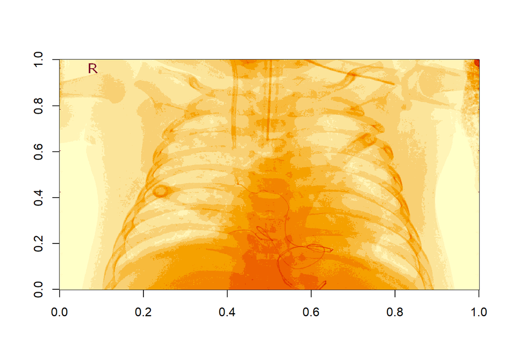

```r
img <- readImage(shuffled_train_dataset[5])

T_img <- torch_squeeze(torch_tensor(img)) %>%
        # Randomly change the brightness, contrast and saturation of an image
        transform_color_jitter() %>%
        # Horizontally flip an image randomly with a given probability
        transform_random_horizontal_flip() %>%
        # Vertically flip an image randomly with a given probability
        transform_random_vertical_flip(p = 0.5)

image(as.array(T_img))
```

```r
# Define a custom dataset class with transformations
ImageDataset_augment <- dataset(
  name = "ImageDataset",
  initialize = function(X, y, transform = NULL) {
    self$transform <- transform
    self$data <- X
    self$labels <- y
  },
  .getitem = function(i) {
    # Return a single sample and label
    x <- self$data[i,,,]
    x <- self$transform(x)
    y <- self$labels[i]

    list(x = x, y = y)
  },
  .length = function() {
    dim(self$data)[1]
  }
)

# Define the transformations for training data
train_transforms <- function(img) {
  img <- torch_squeeze(torch_tensor(img)) %>%
    transform_color_jitter() %>%
    transform_random_horizontal_flip() %>%
    transform_random_vertical_flip(p = 0.5) %>%
    torch_unsqueeze(dim = 1)

  return(img)
}

# Apply the transformations to your training dataset
train_dataset <- ImageDataset_augment(train_X, train_y, transform = train_transforms)
test_dataset <- ImageDataset(test_X, test_y)
val_dataset <- ImageDataset(val_X, val_y)

# Create a dataloader for training
train_dataloader <- dataloader(train_dataset, batch_size = 16)
test_dataloader <- dataloader(test_dataset, batch_size = 16)
val_dataloader <- dataloader(val_dataset, batch_size = 16)

# Iterate over batches of data
batch = train_dataloader$.iter()$.next()

# Visualize the first batch size
batch[[1]]$size()
```

```
## [1]  16   1 224 224
```

### #Q 6: What are the potential drawbacks or disadvantages of data augmentation?

**Data augmentation** is very powerful technique that can improve the model generalization.

Drawbacks also exisit for data augmentation:

1. Increased Training Time

2. Risk of sorting critical consitions

3. Computational Overhead

> Hence, data augmentation need to be applied carefully and contextually.

### #Q 7: What is ImageNet aka “ImageNet Large Scale Visual Recognition Challenge 2012”? How many images and classes does it involve? Why might this help us?

**ImageNet** is a large-scale visual database designed for use in object recognition research. It became widely known through the **ImageNet Large Scale Visual Recognition Challenge (ILSVRC)**, first held in 2010.

In the **2012 competition**, deep learning models like AlexNet revolutionized the field by achieving a significant jump in accuracy over traditional methods.

### Key Facts about ImageNet (ILSVRC 2012):

- Over **1.2 million labeled images** in the training set
- **1,000 distinct object categories**
- Images are richly annotated and vary in viewpoint, lighting, and context

**General visual features** such as: - Edges - Textures - Shapes - Spatial hierarchies, might help the model.

### #Q 8: Why do you think using this architecture in this practical assignment can help to improve the results?

**MobileNet** is a lightweight, efficient CNN architecture designed specifically for devices with limited computing power, such as mobile and embedded devices. Despite being compact, it delivers strong performance for image classification tasks.

### Key features of MobileNet:

- Depthwise separable convolutions
- Fewer parameters
- Pretrained on ImageNet

### How MobileNet helps in this assignment:

- Faster training and inference
- Less prone to overfitting
- Better generalization
- Efficient memory usage
- Good baseline

### Comparison with other popular Torch architectures:

| Model | Parameter Count (Approx.) |
| --- | --- |
| **MobileNetV2** | **~2.5M** |
| ResNet18 | ~11M |
| ResNet50 | ~23M |
| VGG16 | ~138M |
| DenseNet121 | ~8M |

### Also,

- **MobileNetV2 is lightweight**
- **DenseNet121** is another compact model, but still heavier than MobileNet.

> Therefore, MobileNet strikes the right balance between speed, simplicity, and accuracy — making it a practical and efficient choice for this pneumonia classification task.

### #Q 10: Using the provided materials in this practical, train a different network architecture. Does this perform better?

I treid training with different architecture ie.. **pretrained MobileNetV2** architecture from the `torchvision` package. But I could not do it successfull, As my system did not support and R is crashing.

```r
SimpleCNN_v2 <- nn_module(
  initialize = function() {
    self$conv1 <- nn_conv2d(1, 8, kernel_size = 5, padding = 2)
    self$pool <- nn_max_pool2d(kernel_size = 2)
    self$conv2 <- nn_conv2d(8, 16, kernel_size = 3, padding = 1)
    self$fc1 <- nn_linear(16 * 56 * 56, 64)
    self$fc2 <- nn_linear(64, 2)
  },

  forward = function(x) {
    x %>%
      self$conv1() %>%
      nnf_relu() %>%
      self$pool() %>%
      self$conv2() %>%
      nnf_relu() %>%
      self$pool() %>%
      torch_flatten(start_dim = 2) %>%
      self$fc1() %>%
      nnf_relu() %>%
      self$fc2()
  }
)
```

```r
model_v2 <- SimpleCNN_v2 %>%
  setup(
    loss = nn_cross_entropy_loss(),
    optimizer = optim_adam,
    metrics = list(luz_metric_accuracy())
  ) %>%
  set_hparams() %>%
  set_opt_hparams(lr = 0.001)
```

```r
fitted_v2 <- model_v2 %>%
  fit(
    train_dataloader,
    epochs = 1,
    valid_data = test_dataloader
  )
```

[output not shown]

## **—END OF THE REPORT—**